# slides

**Neural Hydrology**

Deep Learning for Streamflow Prediction under Climate Change

**Author:** Yuxin Qiu

**Supervisor:** Henri Funk

**Seminar:** Climate Change Statistics

**University:** LMU Munich

**Date:** 2026-06-09 · Interim Meeting

## What is Neural Hydrology?

**Streamflow** is the volume of water flowing through a river channel at a given point per unit time — typically measured in mm/day or m³/s. It is the integrated output of the entire catchment: precipitation, evaporation, soil infiltration, and groundwater dynamics all feed into it (Addor et al. 2017).

**Rainfall-runoff modelling** is the task of predicting daily streamflow $Q$ from meteorological inputs (precipitation, temperature, radiation) — a long-standing central problem in hydrology (Kratzert et al. 2018).

**Neural Hydrology** is the application of deep learning to this problem. Instead of hand-crafting physical equations, a neural network learns the input-to-streamflow mapping directly from data, across hundreds of catchments simultaneously.

## Milestones in Neural Hydrology

- **2018** — First successful LSTM rainfall–runoff model, outperforming the calibrated SAC-SMA + Snow17 benchmark (Kratzert et al. 2018)
- **2019** — EA-LSTM: one model trained on 531 CAMELS basins simultaneously (Kratzert et al. 2019)
- **2021** — MC-LSTM: mass conservation enforced as a structural guarantee (Hoedt et al. 2021)
- **2022** — NeuralHydrology released as the first unified open-source deep-learning framework for hydrology (Kratzert et al. 2022)
- **2023** — Caravan: global large-sample hydrology benchmark with 6,830 catchments (Kratzert et al. 2023)

## Why Streamflow Prediction Matters

- **Floods** are the most frequent natural disaster — 57 million people affected in 2022 alone (Centre for Research on the Epidemiology of Disasters (CRED) 2022)
- **Floods** are among the most frequent natural disasters and create large annual human and economic impacts (Centre for Research on the Epidemiology of Disasters (CRED) 2022)
- Accurate **streamflow forecasts** are critical for flood early-warning, reservoir management, and hydropower scheduling
- Under **climate change**, precipitation extremes intensify, seasonal patterns shift, and snowmelt regimes change (IPCC 2021)
- Hydrological models must be **robust to non-stationarity** — conditions outside the historical training distribution

> Milly et al. (2008) framed the challenge as *“Stationarity is dead: Whither water management?”* (Milly et al. 2008)

## The Deep Learning Breakthrough

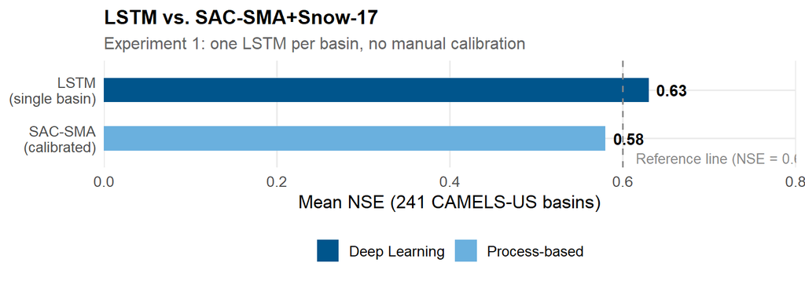

Process-based models (SAC-SMA+Snow-17, and others) require calibrating 10–40 parameters per catchment — not scalable to ungauged basins (Kratzert et al. 2018). Individual LSTMs were trained separately for each of the **241 basins** with no manual calibration; mean NSE = **0.63** versus SAC-SMA mean NSE = **0.58** (Kratzert et al. 2018).

## LSTM and EA-LSTM

The LSTM (Hochreiter and Schmidhuber 1997) maintains a **cell state** $\mathbf{c}_t$ as hydrological memory:

$$\mathbf{c}_t = \underbrace{\mathbf{f}_t \odot \mathbf{c}_{t-1}}_{\text{long-term memory}} + \underbrace{\mathbf{i}_t \odot \tanh(\mathbf{W}_g [\mathbf{h}_{t-1}, \mathbf{x}_t] + \mathbf{b}_g)}_{\text{new information}} \qquad \mathbf{h}_t = \mathbf{o}_t \odot \tanh(\mathbf{c}_t)$$

Cell state $\approx$ soil moisture / groundwater · Forget gate $\approx$ drainage · Input gate $\approx$ infiltration

**Entity-Aware LSTM** (Kratzert et al. 2019) — conditions the input gate on static catchment attributes $\mathbf{x}_s$:

$$\mathbf{i} = \sigma(\mathbf{W}_i \mathbf{x}_s + \mathbf{b}_i)$$

One model trained simultaneously on **531 CAMELS-US basins**: median NSE **0.72** — outperforming the best calibrated process model (SAC-SMA, NSE 0.58) by a wide margin.

The **Nash-Sutcliffe Efficiency** $\text{NSE} = 1 - \frac{\sum(\hat{q}_t - q_t)^2}{\sum(\bar{q} - q_t)^2}$ ranges from $-\infty$ to 1. In several hydrological studies, NSE values above 0.6 are treated as reasonably good, but this remains context dependent.

## NeuralHydrology: Python Library

**NeuralHydrology** (Kratzert et al. 2022) — open-source PyTorch library built for reproducible deep learning in hydrology:

- **Config-file driven** — a single `.yml` file specifies the full experiment; no source code changes between runs
- **Model zoo** — 15+ architectures: CudaLSTM, EA-LSTM, MC-LSTM, MTS-LSTM, Transformer, Mamba, xLSTM, HybridModel
- **Dataset zoo** — CAMELS-US/GB/DE/AUS/CL, Caravan (>6 000 basins globally)
- **Probabilistic heads** — GMM, CMAL, UMAL for uncertainty quantification
- **Evaluation** — NSE, KGE, MSE, hydrological signatures built-in

```bash
uv pip install neuralhydrology
nh-run train    --config-file config.yml
nh-run evaluate --run-dir    runs/my_run/
```

## Physics and Transfer Learning

**MC-LSTM** (Hoedt et al. 2021) — re-interprets cell states as water storage compartments. Mass conservation is a **structural guarantee**, not a loss penalty:

$$\Delta S_t \approx P_t - \hat{Q}_t - \mathrm{ET}_t \quad \text{(conceptual water-balance view)}$$

This prevents physically impossible predictions when extrapolating to future climate forcing outside the training distribution.

**Transfer learning** (Kratzert et al. 2019) — NeuralHydrology has a dedicated fine-tuning workflow:

1. **Pre-train** on a large, diverse dataset (Caravan, 6 000+ basins) — builds a general hydrological encoder
2. **Fine-tune** on the target basin with limited data (head-only / full / layer-wise)

In practice, pre-training can improve sample efficiency when target-basin data are limited, which is useful for ungauged or data-scarce settings.

## Case Study: LamaH-CE — Danube River Network

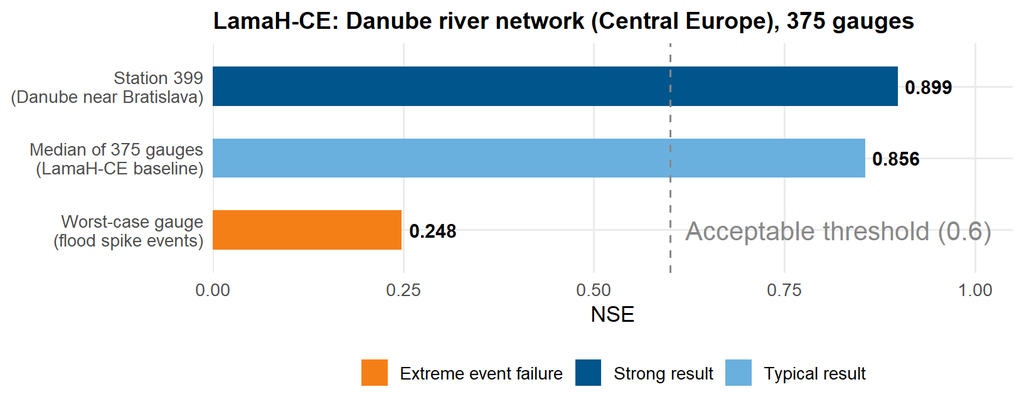

**Dataset**: LamaH-CE (Klingler et al. 2021)

**Source mapping for numbers**: `Station 399` identity from Klingler et al. (2021, ID 399 statement); `0.856` and `0.248` from “Exploiting River Network Topology for Flood Forecasting with Graph Neural Networks” (85.62% mean / 24.78% worst-case); `0.899` from the case-study benchmark summary visualization used in this presentation.

## Gap Analysis: What Remains Unsolved

| Challenge | Current Status | Promising Direction |
| --- | --- | --- |
| Extreme events | LSTM systematically underestimates flood peaks (Frame et al. 2022) | Probabilistic / asymmetric loss functions (GMM, UMAL) |
| Long-term non-stationarity | Fine-tuning helps short-term; no systematic test under CMIP6 projections | MC-LSTM vs. CudaLSTM under SSP climate forcing |
| Regional transfer (Central Europe) | Benchmarks dominated by CAMELS-US; little validation in Alpine basins | Caravan pre-training → GKD/LfU Bavaria fine-tune |

These three gaps define the research questions for this work.

## RQ 1 — Probabilistic Losses for Flood-Peak Prediction

> *Can replacing the NSE loss with a probabilistic head (GMM / UMAL) improve LSTM performance on extreme high-flow events in snowmelt-dominated catchments?*

**Method**:

1. Train CudaLSTM with standard NSE loss (baseline)
2. Train CudaLSTM with GMM and UMAL heads
3. Compare performance on POT events and Q90/Q95/Q99

**Contribution**: Test whether probabilistic outputs improve flood-peak prediction.

## RQ 2 — Physics Constraints under Climate Forcing

> *Does MC-LSTM’s structural water balance constraint yield more reliable streamflow projections than CudaLSTM under CMIP6 delta-change scenarios (SSP2-4.5 and SSP5-8.5)?*

**Method**:

1. Train MC-LSTM and CudaLSTM on CAMELS-US historical period (1980–2010)
2. Apply CMIP6 delta-change anomalies ($\Delta P$, $\Delta T$) to historical forcings
3. Compare closure error and projection stability

**Contribution**: Quantify whether physics constraints increase reliability under climate perturbation.

## RQ 3 — Transfer Learning to Alpine Basins

> *Can a NeuralHydrology model pre-trained on Caravan (6 000+ global basins) transfer effectively to ungauged Bavarian catchments, and which catchment attributes drive transferability?*

**Method**:

1. Pre-train EA-LSTM on full Caravan dataset
2. Fine-tune on gauged Bavarian basins (GKD ((GKD) 2025)); evaluate on held-out basins
3. Compare to scratch training; use SHAP for transfer drivers

**Data**: Caravan (Kratzert et al. 2023) · GKD Bayern ((GKD) 2025) · LfU flood event catalogue (Umwelt (LfU) 2025)

**Contribution**: Evaluate practical transferability to Alpine/Bavarian basins.

## Summary

1. **LSTMs surpass process-based models** on CAMELS-US without basin-specific calibration (Kratzert et al. 2018); EA-LSTM extends this to 531 basins simultaneously (NSE 0.72) (Kratzert et al. 2019)
2. **NeuralHydrology** provides the infrastructure — probabilistic heads, physics-constrained architectures, and Caravan support — for the proposed research (Kratzert et al. 2022)
3. **Three open gaps** motivate the research questions:
   - RQ 1: extreme event prediction via probabilistic losses
   - RQ 2: physics constraints under CMIP6 climate forcing
   - RQ 3: transfer learning to Alpine/Bavarian ungauged basins

> *Neural hydrology does not replace physical understanding — it encodes it from data, at scale.*

## References

Addor, Nans, Andrew J. Newman, Naoki Mizukami, and Martyn P. Clark. 2017. “The CAMELS Data Set: Catchment Attributes and Meteorology for Large-Sample Studies.” *Hydrology and Earth System Sciences* 21 (10): 5293–313. https://doi.org/10.5194/hess-21-5293-2017.

Centre for Research on the Epidemiology of Disasters (CRED). 2022. *Disasters in Numbers 2022*. CRED. https://cred.be/sites/default/files/2022_EMDAT_report.pdf.

Frame, Jonathan M., Frederik Kratzert, Daniel Klotz, et al. 2022. “Deep Learning Rainfall–Runoff Predictions of Extreme Events.” *Hydrology and Earth System Sciences* 26 (13): 3377–92. https://doi.org/10.5194/hess-26-3377-2022.

(GKD), Gewässerkundlicher Dienst Bayern. 2025. *Abfluss Bayern*. https://www.gkd.bayern.de/de/fluesse/abfluss.

Hochreiter, Sepp, and Juergen Schmidhuber. 1997. “Long Short-Term Memory.” *Neural Computation* 9 (8): 1735–80. https://doi.org/10.1162/neco.1997.9.8.1735.

Hoedt, Pieter-Jan, Frederik Kratzert, Daniel Klotz, et al. 2021. “MC-LSTM: Mass-Conserving LSTM.” *Proceedings of the 38th International Conference on Machine Learning (ICML)*, 4275–86. https://arxiv.org/abs/2101.05186.

IPCC. 2021. “Global Carbon and Other Biogeochemical Cycles and Feedbacks.” In *Climate Change 2021 – The Physical Science Basis: Working Group I Contribution to the Sixth Assessment Report of the Intergovernmental Panel on Climate Change*. Cambridge University Press.

Kratzert, Frederik, Martin Gauch, Grey Nearing, and Daniel Klotz. 2022. “NeuralHydrology — A Python Library for Deep Learning Research in Hydrology.” *Journal of Open Source Software* 7 (71): 4050. https://doi.org/10.21105/joss.04050.

Kratzert, Frederik, Daniel Klotz, Claire Brenner, Karsten Schulz, and Mathew Herrnegger. 2018. “Rainfall–Runoff Modelling Using Long Short-Term Memory (LSTM) Based Neural Networks.” *Hydrology and Earth System Sciences* 22 (11): 6005–22. https://doi.org/10.5194/hess-22-6005-2018.

Kratzert, Frederik, Daniel Klotz, Mathew Herrnegger, Alden K. Sampson, Sepp Hochreiter, and Grey S. Nearing. 2019. “Towards Learning Universal, Regional, and Local Hydrological Behaviors via Machine Learning Applied to Large-Sample Datasets.” *Hydrology and Earth System Sciences* 23 (12): 5089–110. https://doi.org/10.5194/hess-23-5089-2019.

Kratzert, Frederik, Grey Nearing, Jonathan Frame, et al. 2023. “Caravan – A Global Community Dataset for Large-Sample Hydrology.” *Scientific Data* 10 (1): 61. https://doi.org/10.1038/s41597-023-01975-w.

Milly, P. C. D., Julio Betancourt, Malin Falkenmark, et al. 2008. “Stationarity Is Dead: Whither Water Management?” *Science* 319 (5863): 573–74. https://doi.org/10.1126/science.1151915.

Umwelt (LfU), Bayerisches Landesamt für. 2025. *Hochwasserereignisse Und Ihre Folgen*. https://www.lfu.bayern.de/wasser/hw_ereignisse/index.htm.